# Introduction to Multivariate Regression & Econometrics

# 1 Student Introductions

## 1.1 Student introductions

1. Preferred name
2. Preferred pronouns
3. Academic program (and how far along)
4. GA, RA, TA, and/or job?
5. Why are you interested in this course?

# 2 About your instructor

## 2.1 Karina Salazar, instructor

My start in statistical analysis

- Began taking quantitative methods courses as a Master’s student
  - Material did not come easy to me! I took intro course twice!
  - Took statistics courses in sociology
  - Causal inference courses at The University of Michigan
- Developed strong data skills
  - Getting data ready for analysis is often very time and labor intensive!
  - Learned data management skills in SPSS and Stata
  - Learned data science skills in Python and R
- Applied what I was learning in class.
  - Worked in assessment and institutional research offices; evaluated retention programs
  - Research assistantship in sociology; worked with national datasets (IPEDS, Survey of Earned Doctorates, Higher Education R&D Survey)
- Sought out teaching opportunities.
  - TA for HED regression and data management courses
  - Delivered practioner-based workshops

## 2.2 Enrollment Management Research Program

- Grew tired of mainstream access inequality policy discourse…
  - Onus on students, families, and K-12 schools
  - Enrollments can only tell us so much
- Do the enrollment management policies and practices of public universities undermine access for underserved student populations?
  - Universities say they care about low-income students, Students of Color
  - But who do they actually recruit? Use data science to collect recruiting events!
- Policy implications
  - Too many policy decisions for increasing access attempt to “fix” student behavior
  - Assumption: doubling low-income, Students of Color applying to a university will double their enrollment

Examples:

- [The off-campus recruiting project](https://emraresearch.org/)
- [Dissertation Defense](https://ksalazar3.github.io/defense/#/title)

# 3 What is Econometrics?

## 3.1 Econometrics (also “Program Evaluation”, Causal Inference)

**Econometrics** is the main methodological strategy used to assess the impact of programs, policies, and interventions.

The goal of econometrics is to determine the **causal effect** of the “program, policy, or treatment” (*the independent variable of interest*) on some educational outcome (*the dependent variable*) by inferring what would have happened in the absence of the “program, policy, or treatment” (*the counterfactual*).

- Do smaller classes improve learning?
- Does offering students financial incentives increase college completion?
- Is online instruction as effective as in-class instruction?

Causal relationships vs. descriptive statistics

- We often infer causality from correlation
- Ice cream consumption causes drownings vs drownings rise when ice cream consumption increases
- Smaller classes cause more learning vs. students in smaller classes have higher test scores

## 3.2 Example

[figure not shown]

## 3.3 Econometrics & Regression

**Regression is used to answer both descriptive and causal questions**

- One is not better than the other, they’re just different types of research questions!
- You can use the same skills to answer both types of ?s via regression

**Why learn regression from an econometrics lens?**

*If you decide to pursue econometrics research*:

- Using regression to overcome *selection bias* in *the independent variable of interest* is the first “tool” in a methodologist’s causal inference toolkit.
- Provides the foundation for more rigorous tools
  - e.g., Difference-in-Difference, Propensity Score Matching, Regression Discontinuity

*If you decide not to pursue econometrics research*:

- It’s easier to learn the fundamentals of regression by focusing on **one** relationship
- Forces you to be thoughtful and intentional about what variables you include in regression models even when you’re focusing on descriptive relationships
  - Avoid the “throwing everything but the kitchen sink” approach to regression modeling

# 4 What is R

## 4.1 What is R

According to the Inter-university consortium for political and social research [(ICPSR)](https://www.icpsr.umich.edu/icpsrweb/content/shared/ICPSR/faqs/what-is-r.html):

> R is “an alternative to traditional statistical packages such as SPSS, SAS, and Stata such that it is an extensible, open-source language and computing environment for Windows, Macintosh, UNIX, and Linux platforms. Such software allows for the user to freely distribute, study, change, and improve the software under the [Free Software Foundation’s GNU General Public License](https://www.gnu.org/home.en.html).”
- For more info visit [R-project.org](https://www.r-project.org/about.html)

## 4.2 Base R vs. R packages

There are “default” packages that come with [R](https://stat.ethz.ch/R-manual/R-devel/library/base/html/00Index.html). Some of these include:

- `as.character`
- `print`
- `setwd`

And there are [R packages](http://r-pkgs.had.co.nz/intro.html) developed and shared by others. Some R packages include:

- `tidyverse`
- `stargazer`
- `equiomatic`

more about these in later weeks…

## 4.3 RStudio

“[RStudio](https://www.rstudio.com/products/rstudio/features/) is an integrated development environment (IDE) for R. It includes a console, syntax-highlighting editor that supports direct code execution, as well as tools for plotting, history, debugging and workspace management.”

[figure not shown]

## 4.4 R Markdown

[R Markdown](https://rmarkdown.rstudio.com/) produces dynamic output formats in html, pdf, MS Word, dashboards, Beamer presentations, etc.

## 4.5 Why R? Capabilities of R

- [Modeling](http://r-statistics.co/Linear-Regression.html)
- [Graphs](https://ggplot2.tidyverse.org/)
- [Presentation](https://bookdown.org/yihui/rmarkdown/presentations.html)
- [Websites](https://bookdown.org/yihui/rmarkdown/websites.html)
- [Journals](https://bookdown.org/yihui/rmarkdown/journals.html)
- [Interactive tutorials](https://rstudio.github.io/learnr/)
- [Web apps](http://shiny.rstudio.com/)
- [Dashbaords](https://rmarkdown.rstudio.com/flexdashboard/)
- [Books](https://bookdown.org/)
- [Web scraping](https://www.analyticsvidhya.com/blog/2017/03/beginners-guide-on-web-scraping-in-r-using-rvest-with-hands-on-knowledge/)
- [Maps](http://pierreroudier.github.io/teaching/20170626-Pedometrics/20170626-soil-data.html)

For more info [visit](https://bookdown.org/yihui/rmarkdown/)

## 4.6 Modeling

Run just about any modeling technique! This course will focus on linear regression…

**Population Regression Model:**

- $Y_{i} = \beta_{0} + \beta_{1}X_{i} + u_{1}$

**OLS Prediction Line:**

- $\hat{Y_{i}} = \hat{\beta_{0}} + \hat{\beta_{1}}X_{i}$

**What is the effect of engine size (cylinder count) on mpg?**

- $\hat{\text{mpg}} = \hat{\beta_{0}} + \hat{\beta_{1}}(\text{cyl})$

```r
#remotes::install_github("datalorax/equatiomatic")
library(equatiomatic)
mod1 <- lm(mpg ~ cyl, mtcars)
```

```r
extract_eq(mod1, use_coefs = TRUE)
```

$$\operatorname{\widehat{mpg}} = 37.88 - 2.88(\operatorname{cyl})$$

## 4.7 Graphs

- Create graphs with [ggplot2](https://ggplot2.tidyverse.org/) package

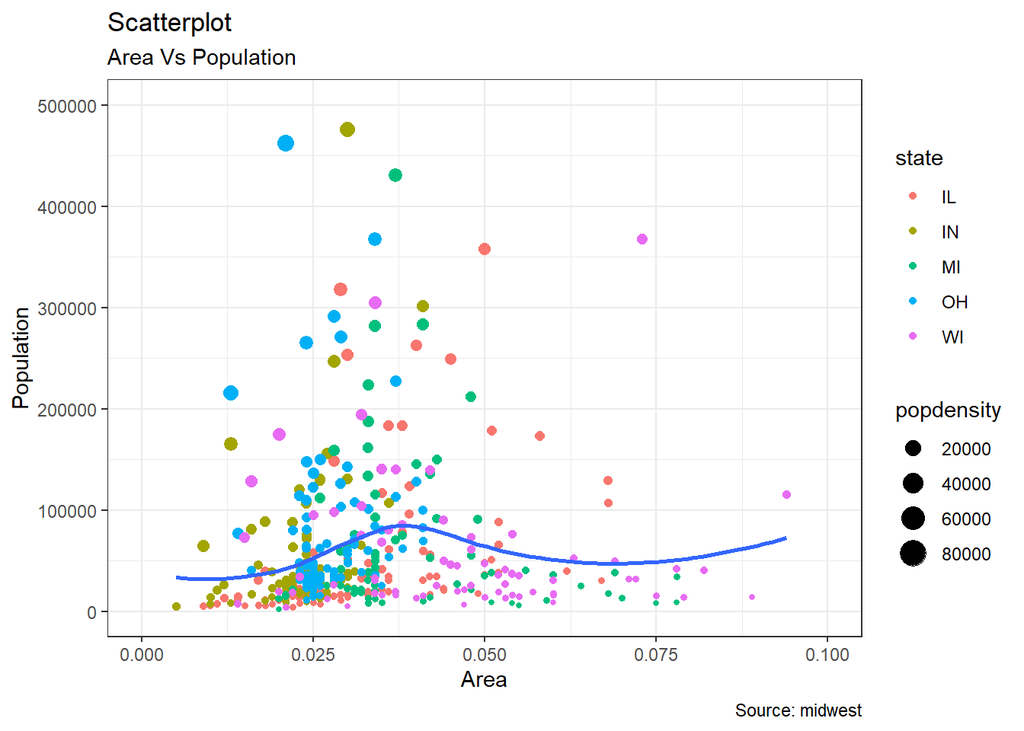

## 4.8 Journal articles

- Journal articles with rticles package

[figure not shown]

## 4.9 Interactive web apps

- Interactive web apps with [shiny](http://shiny.rstudio.com/) package

[figure not shown]

## 4.10 Mapping

- Mapping with [sf](http://strimas.com/r/tidy-sf/) package & ggplot

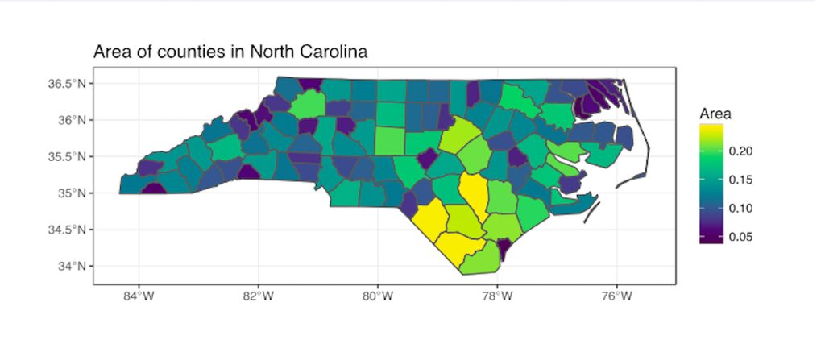

# 5 R Basics

## 5.1 R as a calculator

```r
5
```

```
#> [1] 5
```

```r
5+2
```

```
#> [1] 7
```

```r
10*3
```

```
#> [1] 30
```

## 5.2 Executing commands in R

```r
5
```

```
#> [1] 5
```

```r
5+2
```

```
#> [1] 7
```

```r
10*3
```

```
#> [1] 30
```

Three ways to execute commands in R

1. Type/copy commands directly into the “console”
2. `code chunks’ in RMarkdown (.Rmd files)
   - Can execute one command at a time, one chunk at a time, or “knit” the entire document
3. R scripts (.R files)
   - This is just a text file full of R commands
   - Can execute one command at a time, several commands at a time, or the entire script

## 5.3 Assignment

**Assignment** means creating a variable – or more generally, an “object” – and assigning values to it

- `<-` is the assignment operator
  - in other languages `=` is the assignment operator
- good practice to put a space before and after assignment operator

```r
# Create an object and assign value
a <- 5
a
```

```
#> [1] 5
```

```r
b <- "yay!"
b
```

```
#> [1] "yay!"
```

# 6 Directories and filepaths

## 6.1 Working directory

**(Current) Working directory**

- the folder/directory in which you are currently working
- this is where R looks for files
- Files located in your current working directory can be accessed without specifying a filepath because R automatically looks in this folder

Function `getwd()` shows current working directory

```r
getwd()
```

```
#> [1] "C:/Users/ozanj/Documents/educ152/lectures/karina_lectures/lecture1"
```

Command `list.files()` lists all files located in working directory

```r
getwd()
```

```
#> [1] "C:/Users/ozanj/Documents/educ152/lectures/karina_lectures/lecture1"
```

```r
list.files()
```

```
#>  [1] "abor.png"                     "data-structures-overview.png"
#>  [3] "education.jpg"                "example1.html"
#>  [5] "example1.Rmd"                 "HW1.pdf"
#>  [7] "HW1.Rmd"                      "lecture1.1_ua_files"
#>  [9] "lecture1.aux"                 "lecture1.html"
#> [11] "lecture1.out"                 "lecture1.pdf"
#> [13] "lecture1.Rmd"                 "lecture1.tex"
#> [15] "lecture1.vrb"                 "lecture1_files"
#> [17] "normaldist.jpg"               "normaldist.png"
#> [19] "pane_layout.png"              "professors.png"
#> [21] "rticles.png"                  "sf.png"
#> [23] "shifts.jpg"                   "shifts.png"
#> [25] "shiny.png"                    "UpwardBoundLecture.pdf"
#> [27] "UpwardBoundLecture.Rmd"       "UpwardBoundLecture.tex"
#> [29] "women.png"
```

## 6.2 Absolute vs. relative filepath

**Absolute file path**: The absolute file path is the complete list of directories needed to locate a file or folder.  
`setwd("Users/Karina/rclass/lectures/lecture2")`

**Relative file path**: The relative file path is the path relative to your current location/directory. Assuming your current working directory is in the “lecture2” folder and you want to change your directory to the data folder, your relative file path would look something like this:  
`setwd("../../data")`

```
        File path shortcuts
```

| **Key** | **Description** |
| --- | --- |
| ~ | tilde is a shortcut for user’s home directory (mine is my name) |
| ../ | moves up a level |
| ../../ | moves up two level |

# 7 Create “R project” and directory structure

## 7.1 What is an R project? Why are you doing this?

What is an “R project”?

- helps you keep all files for a project in one place
- When you open an R project, the file-path of your current working directory is automatically set to the file-path of your R-project

Why am I asking you to create R project and download a specific directory structure?

- I want you to be able to run the .R scripts for each lecture on your own computer
- Sometimes these .R scripts point to certain sub-folders in order to open data
- If you create the R project and create directory structure I recommend, you will be able to run .R scripts from your own computer without making any changes to file-paths!

## 7.2 Follow these steps to create “R project” and directory structure

1. Download the zip folder on D2L:
   - Unzip the folder: this is a shell of the file directory you should use for this class
   - Move it to your preferred location (e.g, documents, desktop, dropbox, etc)
2. In RStudio, click on “File” >> “New Project” >> “New Directory” >> “New Project”
   - In “Directory name”, type “hed612_project” as the title of the Rproject for the course
   - In “Create project as subdirectory of”, click browse and:
     - save the R Project within the hed612 folder (same general folder as data and lectures)

## 7.3 After you follow these steps

- You can add any additional sub-folders you want to the “HED612” folder
  - e.g., “syllabus”, “homework”
- You can add any additional files you want to the sub-directory folders you unzipped
  - e.g., in “HED612/lectures/lecture1” you might add an additional document of notes you took

# 8 Next Week

Next week will focus on reviewing intro statistics

**Reading**

- Heiss, pages 1-24 (stop at import/export of text files)
- Stock & Watson Chapter 3
  - Read/skim if you feel a bit rusty on some of the foundational concepts (t-tests, correlations, confidence intervals)

**Problem Set #1**

- Due next Wednesday 1/20/2021 at 4:15pm
- Just giving you some practice with working within an R script and changing “working directories” via relative/absolute filepath